# speed-dating

laybson

26 de julho de 2018

```r
data_sd <- read.csv("speed-dating/speed-dating.csv")
data_sd <- data_sd %>%
  mutate(age_diff = age_o-age)
```

## Ser divertido é ser atraente?

É de saber popular que as pessoas se sentem mais atraídas por pessoas que elas consideram divertidas. Isso faz sentido, uma vez que rir faz bem. Mas será que isso reflete a realidade?

Utilizaremos dados advindos de um [estudo](http://faculty.chicagobooth.edu/emir.kamenica/documents/genderDifferences.pdf) feito por professores da Columbia Business School, onde 310 pessoas participaram de 5000 encontros relâmpagos de 4 minutos, e ao final responderam um questionário onde davam notas de 1 a 10 em características dos parceiros, como: aparência, sinceridade, inteligência, diversão, ambição e interesses em comum. Também davam uma nota geral representando o quanto gostou da pessoa, e uma outra representando a probabilidade da receptividade dela quanto a você, além de responder se interesse de a encontrar novamente.

```r
dados <- data_sd %>%
  mutate(from = as.numeric(factor(from)),
         gender = as.numeric(factor(gender)),
         samerace = as.numeric(factor(samerace)))
```

Os dados obtidos correlacionam-se da seguinte forma:

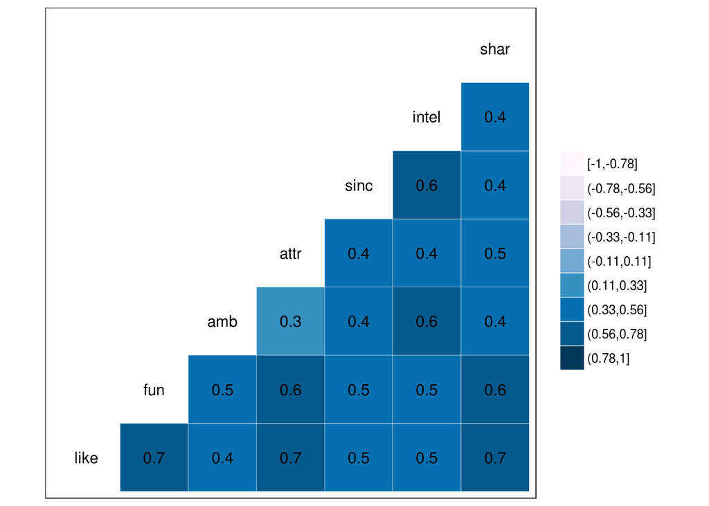

```r
data_sd %>%
  select(like,fun,amb,attr,
         sinc,intel,shar) %>%
  na.omit() %>%
  ggcorr(palette = "PuBu", label = TRUE,
       label_size = 4, nbreaks = 9)
```

Vemos que aparentemente os atributos que melhor se relacionam com a variável gostar, nesse encontros rápidos, são diversão, aparência e interesses em comum. Diversão também mostra certa correlação com aparência e interesses em comum.

Assim se distribui as notas refentes a o quão divertidos os participantes consideraram o seu parceiro:

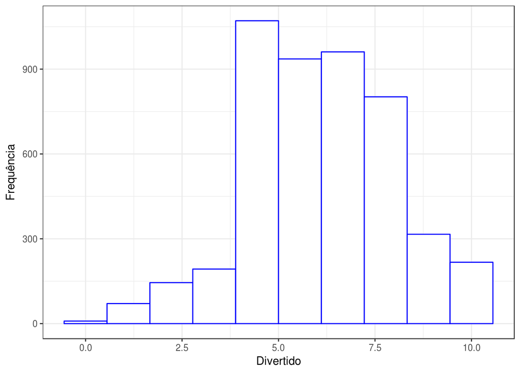

```r
data_sd %>%
    ggplot(aes(x = fun)) +
    geom_histogram(bins = 10, fill = "white", color = "blue") +
    labs(x= "Divertido", y = "Frequência")
```

O histograma acima mostra que a maior parte das pessoas deu notas medianas, entre 5 e 8, para a capacidade de seus parceiros em os divertir.

Abaixo, como se distribui as notas do quanto gostaram da outra pessoa.

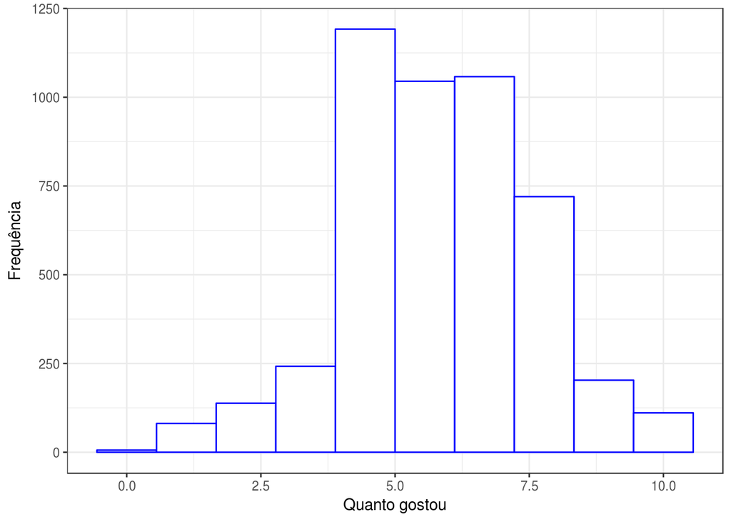

```r
data_sd %>%
    ggplot(aes(x = like)) +
    geom_histogram(bins = 10, fill = "white", color = "blue") +
    labs(x= "Quanto gostou", y = "Frequência")
```

A distribuição é semelhante à de diversão.

Vamos responder nossa pergunta utilizando um modelo de regressão linear:

```r
model <- lm(like ~ fun, data = data_sd)

date_augmented = data_sd %>%
  add_predictions(model) %>%
  add_residuals(model)
```

Avaliando os resíduos do modelo:

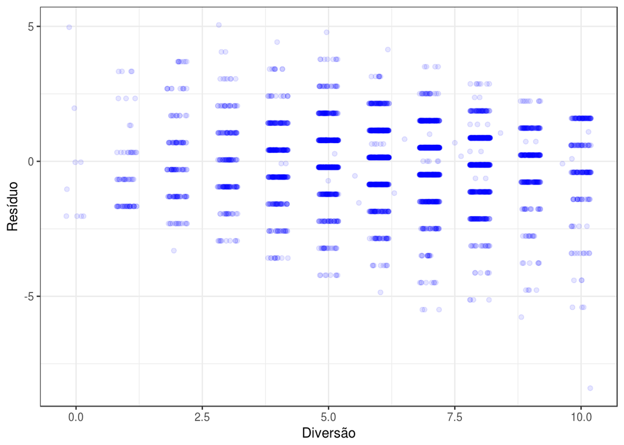

```r
date_augmented %>%
  ggplot(aes(x = fun)) +
  geom_jitter(aes(y = resid), colour = "blue", alpha = .1) +
  labs(x= "Diversão", y = "Resíduo")
```

Observando o gráfico residual, vemos que a maior parte dos erros está entre -3 e 3, dando a entender que o modelo parece representar bem os dados.

```r
tidy(model, conf.int = TRUE) %>%
  select(-std.error, -p.value) %>%
  datatable()
```

|  | term | estimate | statistic | conf.low | conf.high |
| --- | --- | --- | --- | --- | --- |
| 1 | (Intercept) | 2.03193622830813 | 31.0480473334603 | 1.90363359742642 | 2.16023885918984 |
| 2 | fun | 0.637498305401107 | 64.2246982031541 | 0.618038578435574 | 0.65695803236664 |

```r
glance(model) %>%
  datatable()
```

|  | r.squared | adj.r.squared | sigma | statistic | p.value | df | logLik | AIC | BIC | deviance | df.residual |
| --- | --- | --- | --- | --- | --- | --- | --- | --- | --- | --- | --- |
| 1 | 0.467040277239283 | 0.466927050189621 | 1.34475255762082 | 4124.81185928623 | 0 | 2 | -8075.63434392702 | 16157.268687854 | 16176.6403804048 | 8511.9478898589 | 4707 |

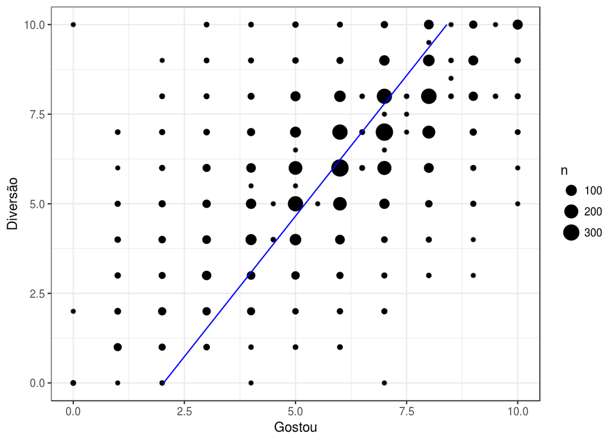

```r
data_sd %>%
    add_predictions(model = model) %>%
    ggplot(aes(x = like, y = fun)) +
    geom_point(alpha = 0.4) +
    geom_count() +
    geom_line(aes(pred), colour = "blue") +
    labs(x= "Gostou", y = "Diversão")  +
    NULL
```

Logo, sim! O mundo está certo! Ser divertido parece ser muito importante para atraírmos parceiros.